# 4.5 Area Under the Standard Normal Curve

## Area Under the Standard Normal Curve

Properties:

1. Total area under the curve is 1.
2. The curve extends infinitely in both directions, never touching the horizontal axis.
3. Symmetric about 0.
4. Almost all of the area under the curve is between -3 and 3.

We work with **cumulative probabilities** or probabilities of the form \(P(Z < z)\).

We will use the fact that the total area under the curve is 1 to find probabilities like \(P(Z > c)\):

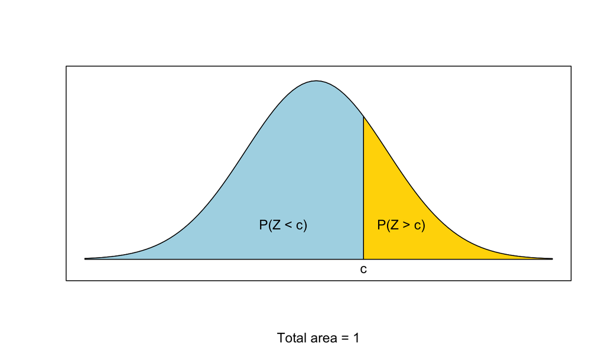

We can also use this concept to find \(P(a < Z < b)\).

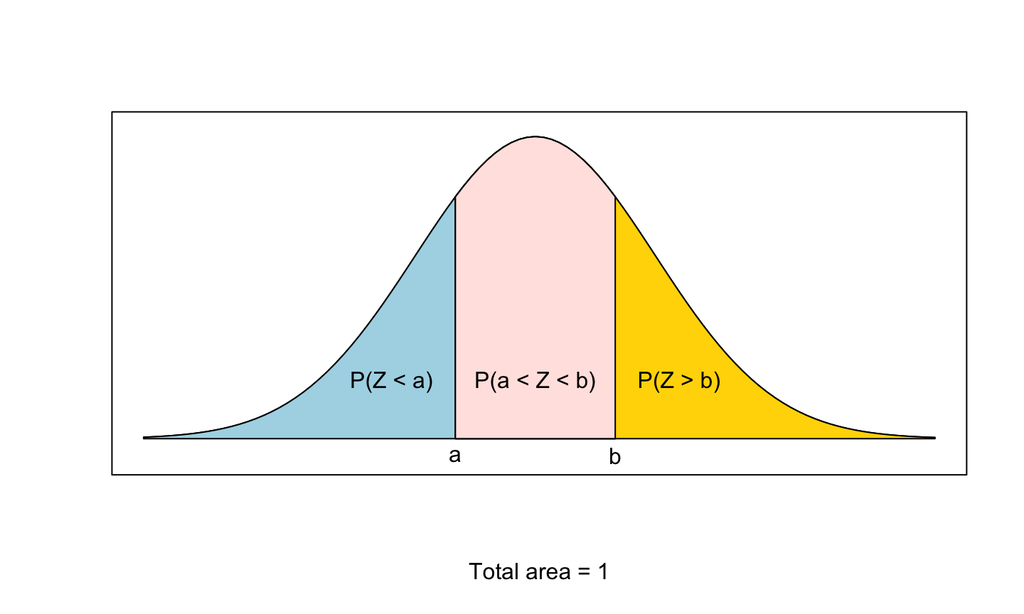

[figure not shown]

Notice that \[1 = P(Z < a) + P(a < Z < b) + P(Z > b)\]

From \[1 = P(Z < a) + P(a < Z < b) + P(Z > b)\] we can write \[P(a < Z < b) = 1 - P(Z > b) - P(Z < a)\] Since we just found that \[P(Z > b) = 1 - P(Z < b)\] we can replace \(1 - P(Z > b)\) with \(P(Z < b)\), and get \[P(a < Z < b) = P(Z < b) - P(Z < a).\]

## Key Cumulative Probability Concepts

- \(P(Z > c) = 1 - P(Z < c)\)
- \(P(a < Z < b) = P(Z < b) - P(Z < a)\)
- The normal distribution is symmetric, so \(P(X < \mu) = P(X > \mu) = 0.5\).

Now that we can get all of our probabilities written as *cumulative* probabilities, we’re ready to use software to find the area under the curve!

## Finding Area Under the Curve: Applets

[Rossman and Chance Normal Probability Calculator](http://www.rossmanchance.com/applets/2021/normcalc/NormCalc.html)

## Example

ACT scores are well-approximated by a normal distribution with mean 20.8 and standard deviation 5.8.

1. Find the probability that a randomly selected test taker scores above a 23.
2. Find the probability that a randomly selected test taker scores between an 18 and a 22.